# lpda: Linear Programming Discriminant Analysis

Carmen Gandía, Department of Mathematics, Alicante Universiy, Spain

Maria J. Nueda, Department of Mathematics, Alicante Universiy, Spain

03 June 2025

**Índex**

1. The method
2. The package
3. The data
4. lpda function
5. lpdaCV function
6. lpda.3D function
7. lpdaCV.3D function
8. References

## 1. The method

Recently, the method has been adapted to 3-dimensional data [2].

## 2. The package

```r
library(lpda)
```

Main function is `lpda` that collect the input data, standardizes the data or applies Principal Component Analysis (PCA) through `lpda.pca` if it is required. Then, it calls to `lpda.fit` as many times as pairwise comparisons there are. The result is a `lpda` type object that is the input to compute predictions through ‘predict’ function and to visualize results through ‘plot’ function.

The package has also a function named `lpdaCV` to compute by crossvalidation (CV) the classification error in different test data sets. This is helpful to decide an appropriate number of PCs or a specific strategy to compute the hyperplane.

`lpda.3D` and `lpdaCV.3D` are designed for dealing with 3-dimensional data.

## 3. The data

`lpda` package includes two data sets concerning data science: `palmdates` and `RNAseq`. The first one is a real data set from a chemometrics study and the second one a simulated RNA-seq experiment. In this document we show the performance of the package with these data sets and with `iris` data, available in `R` package.

### Palmdates data

`Palmdates` is a data set with scores of 21 palm dates including their respective Raman spectra and the concentration of five compounds covering a wide range of concentrations: fibre, glucose, fructose, sorbitol and myo-inositol [1]. The first 11 dates are Spanish (from Elche, Alicante) with no well-defined variety and the last 10 are from other countries and varieties, mainly Arabian. The data set has two data.frames: `conc` with 5 variables and `spectra` with 2050.

```r
data("palmdates")
names(palmdates)
```

```
#> [1] "conc"    "spectra"
```

```r
dim(palmdates$spectra)
```

```
#> [1]   21 2050
```

```r
names(palmdates$conc)
```

```
#> [1] "fibre"        "sorbitol"     "fructose"     "glucose"      "myo-inositol"
```

As `conc` and `spectra`, are very correlated, the application of the method with PCs reduces substantially the dimension.

### RNAseq data

```r
data("RNAseq")
dim(RNAseq)
```

```
#> [1]  20 600   4
```

```r
head(RNAseq[,1:6,1:2])
```

```
#> , , 1
#>
#>      [,1] [,2] [,3] [,4] [,5] [,6]
#> [1,]   70  129   81   86  169  179
#> [2,]   12  153   80  155   85   95
#> [3,]  217   68  136  112  179   96
#> [4,]  109   89   73  194  158  148
#> [5,]   58   92   95   40   59   55
#> [6,]  102   41  188  121   99   95
#>
#> , , 2
#>
#>      [,1] [,2] [,3] [,4] [,5] [,6]
#> [1,]   65   94   95  195  164   95
#> [2,]  101  117  119   92   59  116
#> [3,]   55   67   64   24   54  104
#> [4,]   48   92   68   95   74   86
#> [5,]  221   65   85   81   52   45
#> [6,]   45   13   97   70   76  101
```

## 4. `lpda` function

### Palmdates: Chemical variables

First we apply the method with the first two variables: `fibre` and `sorbitol` to show the performance of the package. The application of the method with two variables allows the visualization of the hyperplane in two dimensions, in this case, a straight line.

```r
   group = as.factor( c(rep("Spanish",11), rep("Other",10)) )
   model1 = lpda(data = palmdates$conc[,1:2], group = group )
   model1
```

```
#> Call:
#> lpda(data = palmdates$conc[, 1:2], group = group)
#> Coefficients:
#> [1] -1.116131 -3.002923 -6.563646
```

```r
   names(model1)
```

```
#> [1] "coef"  "data"  "group" "scale" "pca"   "call"
```

One of the outputs of `lpda` is a matrix with the coefficients of the hyperplane: $a'x=b$ for each pair-wise comparison. In this example, -1.116 and -3.003 the coefficients of `fibre` and `sorbitol` respectively and -6.564 the constant $b$.

In cases with 2 variables, as this simple example, we can plot the line on the points, that represents the samples, with the following code:

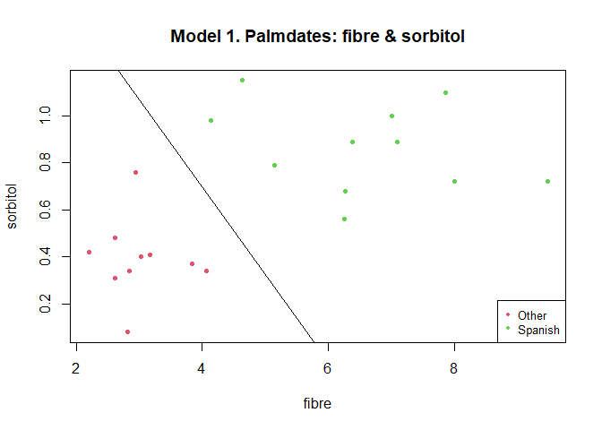

```r
   plot(palmdates$conc[,1:2], col = as.numeric(group)+1, pch = 20,
   main = "Model 1. Palmdates: fibre & sorbitol")
   abline(model1$coef[3]/model1$coef[2], -model1$coef[1]/model1$coef[2], cex = 2)
   legend("bottomright", c("Other","Spanish"),col = c(2,3), pch = 20, cex=0.8)
```

Predicted group with the model is obtained with `predict` function. Confusion matrix can be obtained with `summary`. We observe that all the samples are well classified.

```r
predict(model1)
```

```
#>
#>              elche1              elche2              elche3              elche4
#>           "Spanish"           "Spanish"           "Spanish"           "Spanish"
#>              elche5              elche6              elche7              elche8
#>           "Spanish"           "Spanish"           "Spanish"           "Spanish"
#>              elche9             elche10             elche11      salomon.israel
#>           "Spanish"           "Spanish"           "Spanish"             "Other"
#>       hayani.israel      medjool.israel        barhi.israel   deglet.noor.tunez
#>             "Other"             "Other"             "Other"             "Other"
#>        tunez.alligh argelia.deglet.noor                iran  arabia.saudi.perny
#>             "Other"             "Other"             "Other"             "Other"
#>  sud.africa.medjool
#>             "Other"
```

```r
summary(model1)
```

```
#> Call:
#> lpda(data = palmdates$conc[, 1:2], group = group)
#>
#> CONFUSION MATRIX
#>          Real
#> Predicted Other Spanish
#>   Other      10       0
#>   Spanish     0      11
```

By considering the five concentration variables, all samples are well classified as well. As a 5-dimensional plot can not be showed, we offer the possibility of seeing a plot that shows the situation of samples with respect to $H$. Y-axis represents order in which they appear in the data matrix and X-axis distances of each sample to $H$.

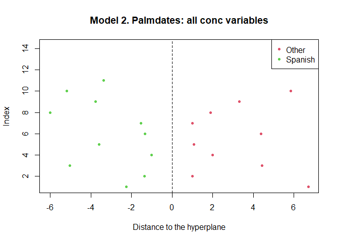

```r
   model2 = lpda(data = palmdates$conc, group = group )
   plot(model2, main="Model 2. Palmdates: all conc variables")
```

Another option is the application of `lpda` to the first PCs scores. When data is highly correlated, two components are usually preferred. In such case choosing as `plot` arguments `PCscores = TRUE` we will visualize the first two PCs, indicating in the axis the proportion of explained variance by each PC. Moreover if there are two groups, as in this example, the optimal hyperplane is also showed.

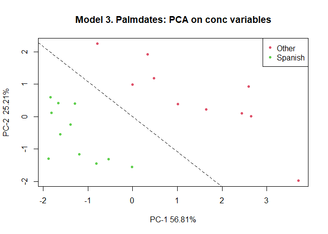

```r
model3 = lpda(data = palmdates$conc, group = group, pca = TRUE, Variability = 0.7)
plot(model3, PCscores = TRUE, main = "Model 3. Palmdates: PCA on conc variables")
```

### Palmdates: Spectra variables

When having data sets with more variables than individuals PCA is not directly applicable. In `lpda` we have implemented the possibility of dealing with such problem, working with the equivalences between the PCA of the data matrix and the transposed matrix.

In `palmdates$spectra` there are 2050 very correlated measurements as it is showed in the following figure:

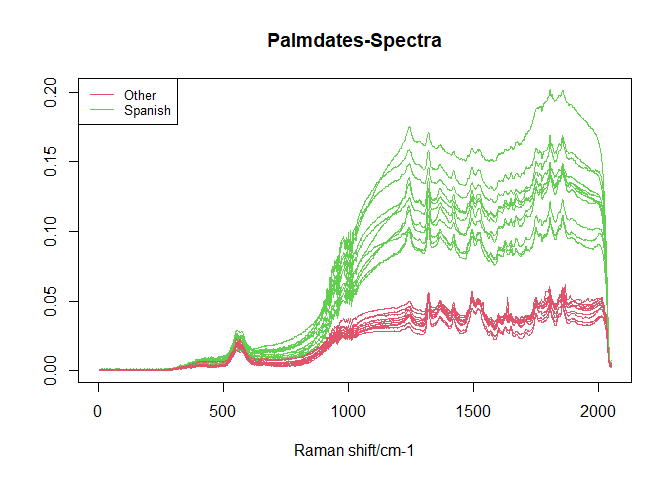

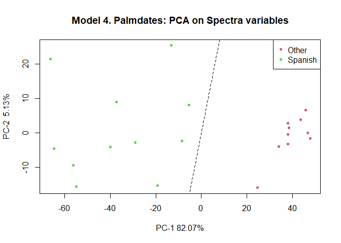

```r
model4 = lpda(data = palmdates$spectra, group = group, pca = TRUE, Variability = 0.9)
plot(model4, PCscores = TRUE, main = "Model 4. Palmdates: PCA on Spectra variables")
```

Following example shows how predict the group of a test set that does not participate in the model. In this set we include two samples of each group.

```r
test = c(10,11,12,13)
model5 = lpda(data = palmdates$spectra[-test,], group = group[-test], pca = TRUE,
              Variability = 0.9)
predict(model5,  datatest=palmdates$spectra[test,])
```

```
#>
#>        elche10        elche11 salomon.israel  hayani.israel
#>      "Spanish"      "Spanish"        "Other"        "Other"
```

```r
summary(model5, datatest=palmdates$spectra[test,], grouptest = group[test])
```

```
#> Call:
#> lpda(data = palmdates$spectra[-test, ], group = group[-test],
#>     pca = TRUE, Variability = 0.9)
#>
#> CONFUSION MATRIX
#>          Real
#> Predicted Other Spanish
#>   Other       2       0
#>   Spanish     0       2
```

### `iris` data

To show an example with more than two groups we use the famous (Fisher’s or Anderson’s) `iris` data set that is available in base `R`. The `iris` data set gives the measurements in centimeters of the variables sepal length and width and petal length and width, respectively, for 50 flowers from each of 3 species of iris. The species are Iris `setosa`, `versicolor`, and `virginica`.

Results with the four variables give 2 classification errors. In this case the model computes 3 hyperplanes for each one of the 3 pairwise comparisons. Now `plot` function gives 3 plots.

```r
model.iris = lpda(iris[,-5], iris[,5])
summary(model.iris)
```

```
#> Call:
#> lpda(data = iris[, -5], group = iris[, 5])
#>
#> CONFUSION MATRIX
#>             Real
#> Predicted    setosa versicolor virginica
#>   setosa         50          0         0
#>   versicolor      0         49         1
#>   virginica       0          1        49
```

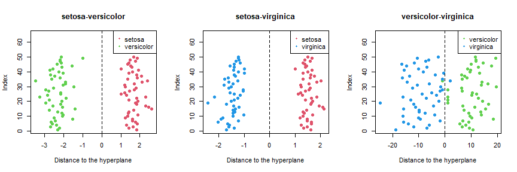

The application of `lpda` with 3 PCs gives the same classification error. Function `plot` with `Pcscores = TRUE` gives the scores in the first two PCs, but in this case without the hyperplanes.

```r
model.iris2 = lpda(iris[,-5], iris[,5], pca=TRUE, PC=3)
summary(model.iris2)
```

```
#> Call:
#> lpda(data = iris[, -5], group = iris[, 5], pca = TRUE, PC = 3)
#>
#> CONFUSION MATRIX
#>             Real
#> Predicted    setosa versicolor virginica
#>   setosa         50          0         0
#>   versicolor      0         49         1
#>   virginica       0          1        49
```

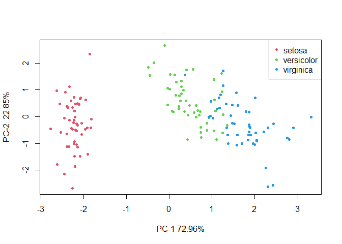

```r
plot(model.iris2, PCscores= TRUE)
```

## 5. `lpdaCV` function

We can use `lpdaCV` function to compute the predicted error in different test sets by crossvalidation with a specific model. Two strategies are implemented: `loo` (leave one out) and `ktest` that is specified in `CV` argument. When `ktest` is selected, `ntest` is the size of test set (samples not used for computing the model, only to evaluate the number of prediction errors) and `R` is the times the model is computed and evaluated with different training and test sets.

```r
lpdaCV(palmdates$spectra, group, pca = TRUE, CV = "loo")
lpdaCV(palmdates$spectra, group, pca = TRUE, CV = "ktest", ntest = 5, R = 10)
```

[output not shown]

```r
  data(RNAseq) # 3-dimensional array
  data = RNAseq[,,3] # the third data matrix with dimensions 20 x 600
  group = as.factor(rep(c("G1","G2"), each = 10))
  model = lpda(data, group) # model with all the variables
  summary(model)
```

[output not shown]

Evaluating the error in several test sets with CV functions we can see that, to avoid overfitting, it is preferable the application of `lpda` with PCA:

```r
lpdaCV(data, group, pca = FALSE, CV = "ktest", ntest = 5)
```

```
#> Call:
#> lpdaCV(data = data, group = group, pca = FALSE, CV = "ktest",
#>     ntest = 5)
#> Prediction Error Rate for analysed model/models:
#> Original Data
#>          0.16
```

```r
lpdaCV(data, group, pca = TRUE, CV = "ktest", ntest = 5)
```

```
#> Call:
#> lpdaCV(data = data, group = group, pca = TRUE, CV = "ktest",
#>     ntest = 5)
#> Prediction Error Rate for analysed model/models:
#> PC-2
#>    0
```

As the success of PCA solution depends on the chosen number of components, there exist the possibility of applying `lpdaCV` for several percentages of explained variability, for PCs from original data, or several number of PCs, specified in a vector. Examples:

```r
set.seed(1)
lpdaCV(data, group, pca = TRUE, CV = "ktest", Variability = c(0.1, 0.9))
```

```
#> Call:
#> lpdaCV(data = data, group = group, pca = TRUE, Variability = c(0.1,
#>     0.9), CV = "ktest")
#> Prediction Error Rate for analysed model/models:
#> Variability-0.1 Variability-0.9
#>            0.02            0.06
```

```r
lpdaCV(data, group, pca = TRUE, CV = "ktest", PC= c(2, 10))
```

```
#> Call:
#> lpdaCV(data = data, group = group, pca = TRUE, PC = c(2, 10),
#>     CV = "ktest")
#> Prediction Error Rate for analysed model/models:
#>  PC-2 PC-10
#>  0.03  0.10
```

## 6. `lpda.3D` function

This function has been designed to apply the method `lpda` to 3-dimensional data through 2 strategies:

1. Applying `lpda` through the third dimension (pfac=FALSE).
2. Applying `lpda` to the parafac scores (pfac=TRUE).

For the second strategy function `parafac` from `multiway` package is used. More details in [2].

```r
  data(RNAseq) # 3-dimensional array
  dim(RNAseq)
```

```
#> [1]  20 600   4
```

```r
  group = as.factor(rep(c("G1","G2"), each = 10))
```

### Strategy 1

```r
  model3D = lpda.3D(RNAseq, group)
  summary(model3D)
```

```
#> CONFUSION MATRIX
#>          Real
#> Predicted G1 G2
#>        G1 10  0
#>        G2  0 10
```

```r
  predict(model3D)
```

```
#>
#>    1    2    3    4    5    6    7    8    9   10   11   12   13   14   15   16
#> "G1" "G1" "G1" "G1" "G1" "G1" "G1" "G1" "G1" "G1" "G2" "G2" "G2" "G2" "G2" "G2"
#>   17   18   19   20
#> "G2" "G2" "G2" "G2"
```

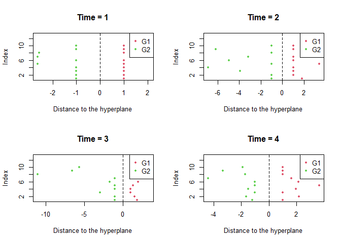

```r
  plot(model3D, mfrow=c(2,2), main =  paste("Time =", c(1:4), sep = " "))
```

### Strategy 2: with parafac

```r
  model3Ds2 = lpda.3D(RNAseq, group, pfac=TRUE, nfac=2)
  model3Ds2$MOD$mod.pfac$Rsq
```

```
#> [1] 0.8094512
```

```r
  predict(model3Ds2)
```

```
#>
#>    1    2    3    4    5    6    7    8    9   10   11   12   13   14   15   16
#> "G1" "G1" "G1" "G1" "G1" "G1" "G1" "G1" "G1" "G1" "G2" "G2" "G2" "G2" "G2" "G2"
#>   17   18   19   20
#> "G2" "G2" "G2" "G2"
```

```r
  summary(model3Ds2)
```

```
#> CONFUSION MATRIX
#>          Real
#> Predicted G1 G2
#>        G1 10  0
#>        G2  0 10
```

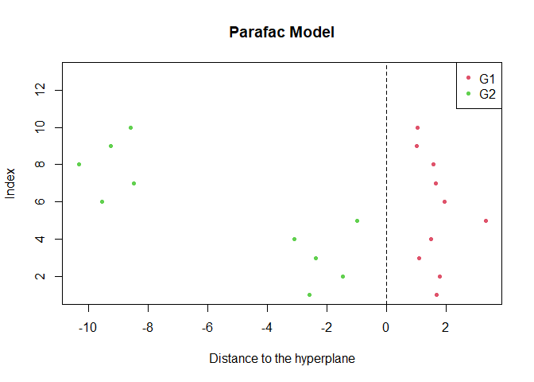

```r
  plot(model3Ds2, pfacscores=FALSE, main="Parafac Model")
```

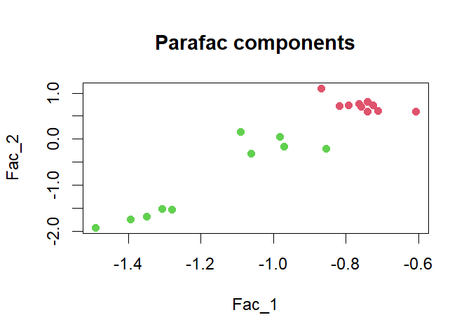

```r
  plot(model3Ds2, pfacscores=TRUE, cex=1.5, main="Parafac components")
```

## 7. `lpdaCV.3D` function

In the same way as `lpdaCV`, this function is useful to evaluate the model and to decide the number of factors in the parafac model.

```r
  lpdaCV.3D(RNAseq, group , CV = "ktest", R=5, ntest=5, pfac=TRUE, nfac=c(2,10))
```

```
#> Call:
#> lpdaCV.3D(data = RNAseq, group = group, pfac = TRUE, nfac = c(2,
#>     10), CV = "ktest", ntest = 5, R = 5)
#> Prediction Error Rate for analysed model/models:
#>  nfac-2 nfac-10
#>    0.00    0.08
```

## 8. References

[1] Abdrabo, S.S.; Gras, L. and Mora, J. (2013) Analytical methods applied to the chemical characterization and classification of palm dates (Phoenix dactylifera L.) from Elche’s Palm Grove. Ph.D. thesis, Departamento de Química Analítica, Nutrición y Bromatología. Universidad de Alicante.

[2] Gandía, C.; Molina, M.D. and Nueda, M.J. (2025) lpda R package: Linear Programming Discriminant Analysis for Multiway data. Submitted.

[3] Nueda, M.J.; Gandía, C. and Molina, M.D. (2022) LPDA: A new classification method based on linear programming. PLOS ONE 17(7): e0270403. https://doi.org/10.1371/journal.pone.0270403

[4] Nueda, M.J.; Gandía, C. and Molina, M.D. Classifying sequencing data using linear programming. Euro30 Conference, Dublin, June-2019.